# 1 GFA_Renamer: Utility for renaming consecutive image files based on a set of names

This is a small utility script written for my internship.  
While I have tested it extensively and can try to maintain it if users require, understand that there are things which will fall outside the scope of this program.

Simply drag a folder containing ordered image files onto the GUI and follow the Instructions.

## 1.1 THE GUI

This program consists of two main GUIs, along an `About`-GUI giving details on used code, version and related information. Relevant images which may help understand the setup of the program can be found at the end of this documentation file.

Figures 1 and 2 show an overview on the two main GUIs.  
Figure 3 outlines the ability to modify the name which is to be assigned to a file.

Then enter the required group names and number of pots per group(s) and confirm your choices.

The image files in that folder will then be duplicated into a subfolder `GFAR_WD`, wherein they will be renamed according to the information provided.

The script additionally provides a log file stating

1. The number of expected files
2. The number of renamed files, and
3. For every file its original and new filename.

The original files will never be altered directly as a precaution.

**It is the user’s responsibility to decide to delete the original backup files**.

## 1.2 How to deal with missing images

In cases where a certain group has fewer images than the other - as could be the case if you loose a single pot at some point due to damage - simply select the image of the **NEXT** pot and create a copy by pressing `Duplicate to shift frame`. Refer to figures 8-10 for visual aid on the process outlined in this section.

Refer to figure 8.  
If we assume that the image for `G14D2` and `G14D3` are missing *initially*, aka in the image above the file `DSC06473` actually contains the image of `G14D4`, select `DSC06473` and press on `Duplicate to shift frame`.

If you need to duplicate the same image more than once, **any duplications required to fill subsequent gaps** must be made of the **padded** image. In this example, if you press the button once, you would get an entry with the expected filepath of `DSC06473 (padding)`. As you need to pad twice, you then select the entry of `DSC06473 (padding)` and repeat the process. If you were to select `DSC06473`, duplicating it again will not work.  
If you would want to bridge a 3-image wide gap, you would duplicate `DSC06473` to `DSC06473 (padding)`, then `DSC06473 (padding)` to `DSC06473 (padding) (padding)`, and finally `DSC06473 (padding) (padding)` to `DSC06473 (padding) (padding) (padding)`.

Example:

You have a group of plants which get watered at half the normal volume for 14 days, and every group has 7 pots.

The pot G14D4 (14 Days at reduced water supply, then back up to normal) was removed because it got dropped a day before.

In this case, all groups have seven images, but the G14-Group only has six. Thus, imagine you have the following images to work with:

| Number | Filename | intended file name/label as seen on pot | file name without frame shift |
| --- | --- | --- | --- |
| 1 | DSC10111.JPG | `G14D1` | `G14D1` |
| 2 | DSC10112.JPG | `G14D2` | `G14D2` |
| 3 | DSC10113.JPG | `G14D3` | `G14D3` |
| 4 | DSC10114.JPG | `G14D5` | `G14D4` |
| 5 | DSC10115.JPG | `G14D6` | `G14D5` |
| 6 | DSC10116.JPG | `G14D7` | `G14D6` |

To prevent this, create a copy of `DSC10113` - it is important that you copy the image of the pot *immediately before the one that is missing*:

| Number | Filename | intended file name/plant label as seen on pot | file name with frame shift |
| --- | --- | --- | --- |
| 1 | DSC10111.JPG | `G14D1` | `G14D1` |
| 2 | DSC10112.JPG | `G14D2` | `G14D2` |
| 3 | DSC10113.JPG | `G14D3` | `G14D3` |
| 4 | DSC10113 - Copy.JPG | `<Placeholder for the missing pot G14D4>` | `<Placeholder for the missing pot G14D4>` |
| 5 | DSC10114.JPG | `G14D5` | `G14D5` |
| 6 | DSC10115.JPG | `G14D6` | `G14D6` |
| 7 | DSC10116.JPG | `G14D7` | `G14D7` |

As the script will read images in the folder based on their name, this method ensures the gap is filled appropriately.

## 1.3 How to deal with varying group sizes

Sometimes you have experiments with several varying group sizes, e.g. a drought stress setup on two axes - stressed vs unstressed, and ABA-treated vs non-treated, which may not have the same group sizes:

| Stress/Treatment | / | ABA |
| --- | --- | --- |
| Stress | Stress (8) | Stress-ABA (5) |
| UU | UU (8) | UU-ABA (5) |

In this case, you would set `Stress,Stress-ABA,UU,UU-ABA` as `groups`, and `8,5,8,5` as group sizes (see figure 4).

# 2 Experimental Playground testset

This repository contains a sample set in the folder `assets\Image Test Files`. It contains the raw images, as well as the resulting output in the subfolder `GFAR_WD`. To use the test-set, use the button `Set Testset`. A message will pop up notifying you if the testset is loaded.  
*Note that if the testset folder does no longer exist, the program will attempt to download it from the source gist host containing these files. Be aware that this may be blocked by Firewalls, computer settings or a lack of internet connection.* The link to the default testset can be found in the About-Section.

# 3 Annex

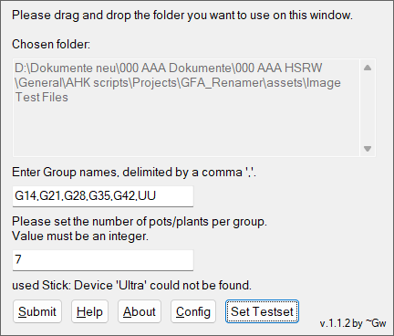

Fig.1: Main GUI Overview

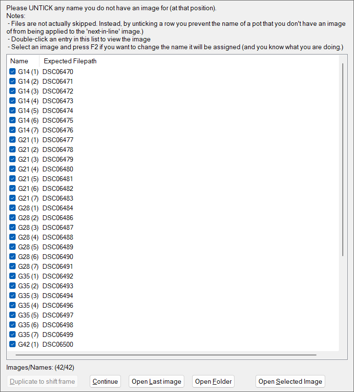

Fig.2: Plant-Name Exclusion GUI: Use this to untick NAMES which do not line up with the expected File. Double-click an image to open the image file itself - do so if you want to verify the files being named correctly

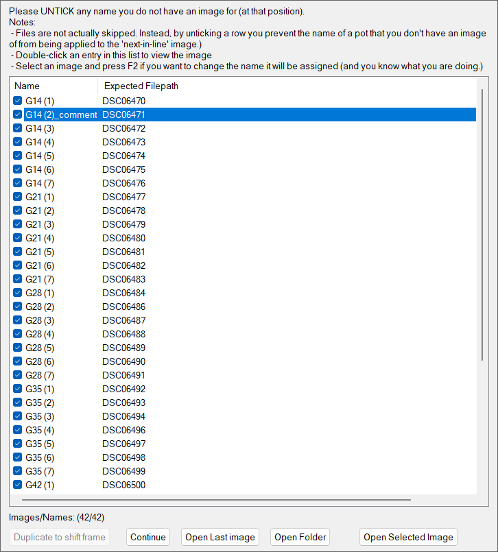

Fig.3: By pressing F2, one can change the name of an image. This can be useful to note errors occurring in the image, f.e. a partially covered pink dot that went unnoticed at time of shooting.

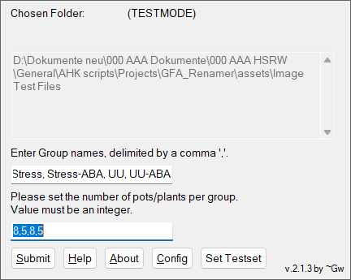

Fig.4: Setting groups of varying sizes

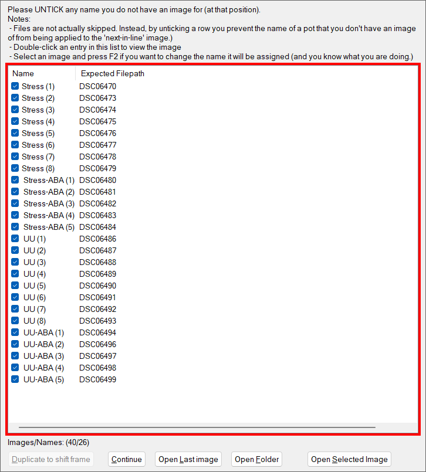

Fig.5: Renaming groups of varying sizes

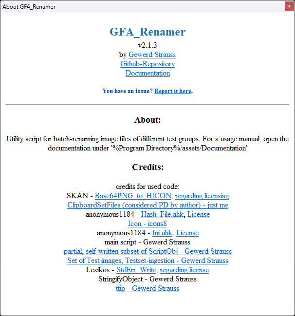

Fig.6: About-Window containing links to the Github-Repository, its documentation, as well as links to all code credited to others - and their licensing requirements, if applicable.

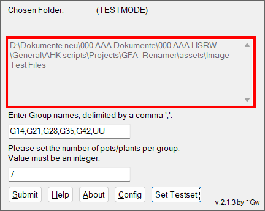

Fig.7: Field outlining the folder which the script operates upon. This also delimits the area upon which the user should drop the folder for selecting it.

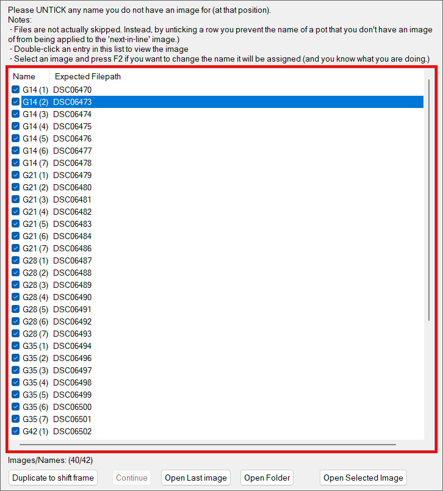

Fig.8: Images for G14D2 and G14D3 are missing (notice that DSC06470 is followed by DSC06473). We need to bridge the gap to avoid a frameshift.

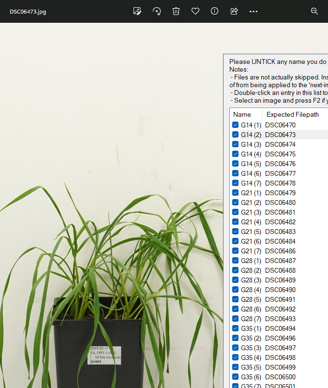

Fig.9: Closeup of `DSC06473` showing that it is indeed the image of Pot `G14D4`

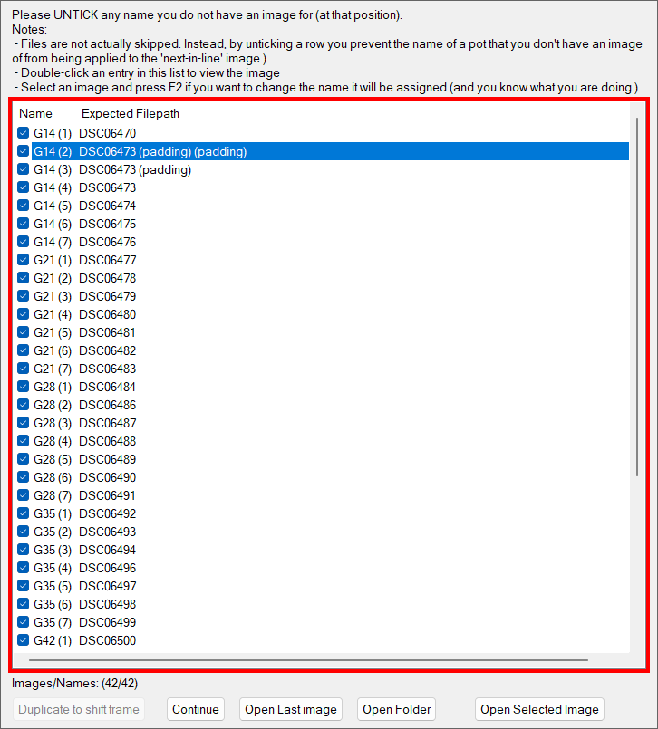

Fig.10: Using two padded images for the missing entries `G14D2-G14D3` to overcome the “frameshift” at these “positions”.

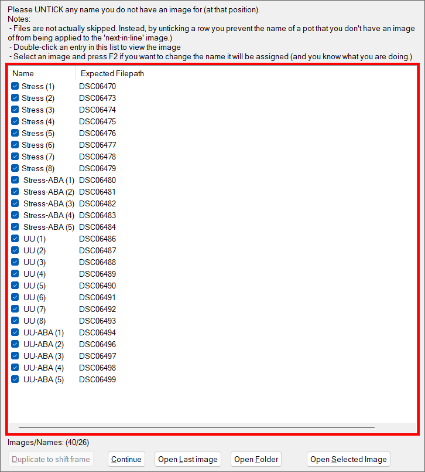

Fig.10: Notice that while below the Listview we have Images/Names (40/26): We have names for 26 images, but the default testset contains 40 images. Obviously, usually you do not want to have more Image than names, and definitely not less images than names